```python
# Mohammad Mahdi Abdolhosseini
# 810 198 434
# AI : CA0
```

```python
import numpy as np
import matplotlib.pyplot as plt
import pandas as pd
import time
from scipy.stats import norm
```

# Q1:

```python
df = pd.read_csv ('train.csv')
df
```

|  | PassengerId | Survived | Pclass | Name | Sex | Age | SibSp | Parch | Ticket | Fare | Cabin | Embarked |
| --- | --- | --- | --- | --- | --- | --- | --- | --- | --- | --- | --- | --- |
| 0 | 1 | 0 | 3 | Braund, Mr. Owen Harris | male | 22.0 | 1 | 0 | A/5 21171 | 7.2500 | NaN | S |
| 1 | 2 | 1 | 1 | Cumings, Mrs. John Bradley (Florence Briggs Th... | female | 38.0 | 1 | 0 | PC 17599 | 71.2833 | C85 | C |
| 2 | 3 | 1 | 3 | Heikkinen, Miss. Laina | female | 26.0 | 0 | 0 | STON/O2. 3101282 | 7.9250 | NaN | S |
| 3 | 4 | 1 | 1 | Futrelle, Mrs. Jacques Heath (Lily May Peel) | female | 35.0 | 1 | 0 | 113803 | 53.1000 | C123 | S |
| 4 | 5 | 0 | 3 | Allen, Mr. William Henry | male | 35.0 | 0 | 0 | 373450 | 8.0500 | NaN | S |
| 5 | 6 | 0 | 3 | Moran, Mr. James | male | NaN | 0 | 0 | 330877 | 8.4583 | NaN | Q |
| 6 | 7 | 0 | 1 | McCarthy, Mr. Timothy J | male | 54.0 | 0 | 0 | 17463 | 51.8625 | E46 | S |
| 7 | 8 | 0 | 3 | Palsson, Master. Gosta Leonard | male | 2.0 | 3 | 1 | 349909 | 21.0750 | NaN | S |
| 8 | 9 | 1 | 3 | Johnson, Mrs. Oscar W (Elisabeth Vilhelmina Berg) | female | 27.0 | 0 | 2 | 347742 | 11.1333 | NaN | S |
| 9 | 10 | 1 | 2 | Nasser, Mrs. Nicholas (Adele Achem) | female | 14.0 | 1 | 0 | 237736 | 30.0708 | NaN | C |
| 10 | 11 | 1 | 3 | Sandstrom, Miss. Marguerite Rut | female | 4.0 | 1 | 1 | PP 9549 | 16.7000 | G6 | S |
| 11 | 12 | 1 | 1 | Bonnell, Miss. Elizabeth | female | 58.0 | 0 | 0 | 113783 | 26.5500 | C103 | S |
| 12 | 13 | 0 | 3 | Saundercock, Mr. William Henry | male | 20.0 | 0 | 0 | A/5. 2151 | 8.0500 | NaN | S |
| 13 | 14 | 0 | 3 | Andersson, Mr. Anders Johan | male | 39.0 | 1 | 5 | 347082 | 31.2750 | NaN | S |
| 14 | 15 | 0 | 3 | Vestrom, Miss. Hulda Amanda Adolfina | female | 14.0 | 0 | 0 | 350406 | 7.8542 | NaN | S |
| 15 | 16 | 1 | 2 | Hewlett, Mrs. (Mary D Kingcome) | female | 55.0 | 0 | 0 | 248706 | 16.0000 | NaN | S |
| 16 | 17 | 0 | 3 | Rice, Master. Eugene | male | 2.0 | 4 | 1 | 382652 | 29.1250 | NaN | Q |
| 17 | 18 | 1 | 2 | Williams, Mr. Charles Eugene | male | NaN | 0 | 0 | 244373 | 13.0000 | NaN | S |
| 18 | 19 | 0 | 3 | Vander Planke, Mrs. Julius (Emelia Maria Vande... | female | 31.0 | 1 | 0 | 345763 | 18.0000 | NaN | S |
| 19 | 20 | 1 | 3 | Masselmani, Mrs. Fatima | female | NaN | 0 | 0 | 2649 | 7.2250 | NaN | C |
| 20 | 21 | 0 | 2 | Fynney, Mr. Joseph J | male | 35.0 | 0 | 0 | 239865 | 26.0000 | NaN | S |
| 21 | 22 | 1 | 2 | Beesley, Mr. Lawrence | male | 34.0 | 0 | 0 | 248698 | 13.0000 | D56 | S |
| 22 | 23 | 1 | 3 | McGowan, Miss. Anna "Annie" | female | 15.0 | 0 | 0 | 330923 | 8.0292 | NaN | Q |
| 23 | 24 | 1 | 1 | Sloper, Mr. William Thompson | male | 28.0 | 0 | 0 | 113788 | 35.5000 | A6 | S |
| 24 | 25 | 0 | 3 | Palsson, Miss. Torborg Danira | female | 8.0 | 3 | 1 | 349909 | 21.0750 | NaN | S |
| 25 | 26 | 1 | 3 | Asplund, Mrs. Carl Oscar (Selma Augusta Emilia... | female | 38.0 | 1 | 5 | 347077 | 31.3875 | NaN | S |
| 26 | 27 | 0 | 3 | Emir, Mr. Farred Chehab | male | NaN | 0 | 0 | 2631 | 7.2250 | NaN | C |
| 27 | 28 | 0 | 1 | Fortune, Mr. Charles Alexander | male | 19.0 | 3 | 2 | 19950 | 263.0000 | C23 C25 C27 | S |
| 28 | 29 | 1 | 3 | O'Dwyer, Miss. Ellen "Nellie" | female | NaN | 0 | 0 | 330959 | 7.8792 | NaN | Q |
| 29 | 30 | 0 | 3 | Todoroff, Mr. Lalio | male | NaN | 0 | 0 | 349216 | 7.8958 | NaN | S |
| ... | ... | ... | ... | ... | ... | ... | ... | ... | ... | ... | ... | ... |
| 861 | 862 | 0 | 2 | Giles, Mr. Frederick Edward | male | 21.0 | 1 | 0 | 28134 | 11.5000 | NaN | S |
| 862 | 863 | 1 | 1 | Swift, Mrs. Frederick Joel (Margaret Welles Ba... | female | 48.0 | 0 | 0 | 17466 | 25.9292 | D17 | S |
| 863 | 864 | 0 | 3 | Sage, Miss. Dorothy Edith "Dolly" | female | NaN | 8 | 2 | CA. 2343 | 69.5500 | NaN | S |
| 864 | 865 | 0 | 2 | Gill, Mr. John William | male | 24.0 | 0 | 0 | 233866 | 13.0000 | NaN | S |
| 865 | 866 | 1 | 2 | Bystrom, Mrs. (Karolina) | female | 42.0 | 0 | 0 | 236852 | 13.0000 | NaN | S |
| 866 | 867 | 1 | 2 | Duran y More, Miss. Asuncion | female | 27.0 | 1 | 0 | SC/PARIS 2149 | 13.8583 | NaN | C |
| 867 | 868 | 0 | 1 | Roebling, Mr. Washington Augustus II | male | 31.0 | 0 | 0 | PC 17590 | 50.4958 | A24 | S |
| 868 | 869 | 0 | 3 | van Melkebeke, Mr. Philemon | male | NaN | 0 | 0 | 345777 | 9.5000 | NaN | S |
| 869 | 870 | 1 | 3 | Johnson, Master. Harold Theodor | male | 4.0 | 1 | 1 | 347742 | 11.1333 | NaN | S |
| 870 | 871 | 0 | 3 | Balkic, Mr. Cerin | male | 26.0 | 0 | 0 | 349248 | 7.8958 | NaN | S |
| 871 | 872 | 1 | 1 | Beckwith, Mrs. Richard Leonard (Sallie Monypeny) | female | 47.0 | 1 | 1 | 11751 | 52.5542 | D35 | S |
| 872 | 873 | 0 | 1 | Carlsson, Mr. Frans Olof | male | 33.0 | 0 | 0 | 695 | 5.0000 | B51 B53 B55 | S |
| 873 | 874 | 0 | 3 | Vander Cruyssen, Mr. Victor | male | 47.0 | 0 | 0 | 345765 | 9.0000 | NaN | S |
| 874 | 875 | 1 | 2 | Abelson, Mrs. Samuel (Hannah Wizosky) | female | 28.0 | 1 | 0 | P/PP 3381 | 24.0000 | NaN | C |
| 875 | 876 | 1 | 3 | Najib, Miss. Adele Kiamie "Jane" | female | 15.0 | 0 | 0 | 2667 | 7.2250 | NaN | C |
| 876 | 877 | 0 | 3 | Gustafsson, Mr. Alfred Ossian | male | 20.0 | 0 | 0 | 7534 | 9.8458 | NaN | S |
| 877 | 878 | 0 | 3 | Petroff, Mr. Nedelio | male | 19.0 | 0 | 0 | 349212 | 7.8958 | NaN | S |
| 878 | 879 | 0 | 3 | Laleff, Mr. Kristo | male | NaN | 0 | 0 | 349217 | 7.8958 | NaN | S |
| 879 | 880 | 1 | 1 | Potter, Mrs. Thomas Jr (Lily Alexenia Wilson) | female | 56.0 | 0 | 1 | 11767 | 83.1583 | C50 | C |
| 880 | 881 | 1 | 2 | Shelley, Mrs. William (Imanita Parrish Hall) | female | 25.0 | 0 | 1 | 230433 | 26.0000 | NaN | S |
| 881 | 882 | 0 | 3 | Markun, Mr. Johann | male | 33.0 | 0 | 0 | 349257 | 7.8958 | NaN | S |
| 882 | 883 | 0 | 3 | Dahlberg, Miss. Gerda Ulrika | female | 22.0 | 0 | 0 | 7552 | 10.5167 | NaN | S |
| 883 | 884 | 0 | 2 | Banfield, Mr. Frederick James | male | 28.0 | 0 | 0 | C.A./SOTON 34068 | 10.5000 | NaN | S |
| 884 | 885 | 0 | 3 | Sutehall, Mr. Henry Jr | male | 25.0 | 0 | 0 | SOTON/OQ 392076 | 7.0500 | NaN | S |
| 885 | 886 | 0 | 3 | Rice, Mrs. William (Margaret Norton) | female | 39.0 | 0 | 5 | 382652 | 29.1250 | NaN | Q |
| 886 | 887 | 0 | 2 | Montvila, Rev. Juozas | male | 27.0 | 0 | 0 | 211536 | 13.0000 | NaN | S |
| 887 | 888 | 1 | 1 | Graham, Miss. Margaret Edith | female | 19.0 | 0 | 0 | 112053 | 30.0000 | B42 | S |
| 888 | 889 | 0 | 3 | Johnston, Miss. Catherine Helen "Carrie" | female | NaN | 1 | 2 | W./C. 6607 | 23.4500 | NaN | S |
| 889 | 890 | 1 | 1 | Behr, Mr. Karl Howell | male | 26.0 | 0 | 0 | 111369 | 30.0000 | C148 | C |
| 890 | 891 | 0 | 3 | Dooley, Mr. Patrick | male | 32.0 | 0 | 0 | 370376 | 7.7500 | NaN | Q |

891 rows × 12 columns

##### تعداد سطرهای دیتافریم، تعداد ستون ها، تعداد داده های غیر نال و دیتاتایپ هر یک را گزارش میکند

```python
df.info()
```

```
<class 'pandas.core.frame.DataFrame'>
RangeIndex: 891 entries, 0 to 890
Data columns (total 12 columns):
PassengerId    891 non-null int64
Survived       891 non-null int64
Pclass         891 non-null int64
Name           891 non-null object
Sex            891 non-null object
Age            714 non-null float64
SibSp          891 non-null int64
Parch          891 non-null int64
Ticket         891 non-null object
Fare           891 non-null float64
Cabin          204 non-null object
Embarked       889 non-null object
dtypes: float64(2), int64(5), object(5)
memory usage: 83.6+ KB
```

##### پنج سطر ابتدایی دیتافریم را گزارش میکند

```python
df.head()
```

|  | PassengerId | Survived | Pclass | Name | Sex | Age | SibSp | Parch | Ticket | Fare | Cabin | Embarked |
| --- | --- | --- | --- | --- | --- | --- | --- | --- | --- | --- | --- | --- |
| 0 | 1 | 0 | 3 | Braund, Mr. Owen Harris | male | 22.0 | 1 | 0 | A/5 21171 | 7.2500 | NaN | S |
| 1 | 2 | 1 | 1 | Cumings, Mrs. John Bradley (Florence Briggs Th... | female | 38.0 | 1 | 0 | PC 17599 | 71.2833 | C85 | C |
| 2 | 3 | 1 | 3 | Heikkinen, Miss. Laina | female | 26.0 | 0 | 0 | STON/O2. 3101282 | 7.9250 | NaN | S |
| 3 | 4 | 1 | 1 | Futrelle, Mrs. Jacques Heath (Lily May Peel) | female | 35.0 | 1 | 0 | 113803 | 53.1000 | C123 | S |
| 4 | 5 | 0 | 3 | Allen, Mr. William Henry | male | 35.0 | 0 | 0 | 373450 | 8.0500 | NaN | S |

##### پنج سطر انتهایی دیتافریم را گزارش میکند

```python
df.tail()
```

|  | PassengerId | Survived | Pclass | Name | Sex | Age | SibSp | Parch | Ticket | Fare | Cabin | Embarked |
| --- | --- | --- | --- | --- | --- | --- | --- | --- | --- | --- | --- | --- |
| 886 | 887 | 0 | 2 | Montvila, Rev. Juozas | male | 27.0 | 0 | 0 | 211536 | 13.00 | NaN | S |
| 887 | 888 | 1 | 1 | Graham, Miss. Margaret Edith | female | 19.0 | 0 | 0 | 112053 | 30.00 | B42 | S |
| 888 | 889 | 0 | 3 | Johnston, Miss. Catherine Helen "Carrie" | female | NaN | 1 | 2 | W./C. 6607 | 23.45 | NaN | S |
| 889 | 890 | 1 | 1 | Behr, Mr. Karl Howell | male | 26.0 | 0 | 0 | 111369 | 30.00 | C148 | C |
| 890 | 891 | 0 | 3 | Dooley, Mr. Patrick | male | 32.0 | 0 | 0 | 370376 | 7.75 | NaN | Q |

##### تعداد داده های غیر نال، میانگین، انحراف معیار، مینیمم و ماکزیمم را گزارش میکند

```python
df.describe()
```

|  | PassengerId | Survived | Pclass | Age | SibSp | Parch | Fare |
| --- | --- | --- | --- | --- | --- | --- | --- |
| count | 891.000000 | 891.000000 | 891.000000 | 714.000000 | 891.000000 | 891.000000 | 891.000000 |
| mean | 446.000000 | 0.383838 | 2.308642 | 29.699118 | 0.523008 | 0.381594 | 32.204208 |
| std | 257.353842 | 0.486592 | 0.836071 | 14.526497 | 1.102743 | 0.806057 | 49.693429 |
| min | 1.000000 | 0.000000 | 1.000000 | 0.420000 | 0.000000 | 0.000000 | 0.000000 |
| 25% | 223.500000 | 0.000000 | 2.000000 | 20.125000 | 0.000000 | 0.000000 | 7.910400 |
| 50% | 446.000000 | 0.000000 | 3.000000 | 28.000000 | 0.000000 | 0.000000 | 14.454200 |
| 75% | 668.500000 | 1.000000 | 3.000000 | 38.000000 | 1.000000 | 0.000000 | 31.000000 |
| max | 891.000000 | 1.000000 | 3.000000 | 80.000000 | 8.000000 | 6.000000 | 512.329200 |

# Q2:

##### در این قسمت بدلیل اینکه میخواهیم تغییراتی را روی دیتافریم اعمال کنیم، یک کپی از آن میگیریم تا اطلاعات اصلی همچنان در دسترس باشد

```python
df_copy = df.copy()
```

##### برای برچسب گذاری به روش زیر عمل میکنیم، در این بخش تنها برچسب گذاری روی ستون جنسیت انجام میشود، همچنین در بخش قبل دسته ای یا عددی بودن هر ستون گزارش شده است

```python
# [male = 1]; [female = 0];
df_copy['Sex'] = df['Sex'].astype('category').cat.codes
df_copy.tail()
```

|  | PassengerId | Survived | Pclass | Name | Sex | Age | SibSp | Parch | Ticket | Fare | Cabin | Embarked |
| --- | --- | --- | --- | --- | --- | --- | --- | --- | --- | --- | --- | --- |
| 886 | 887 | 0 | 2 | Montvila, Rev. Juozas | 1 | 27.0 | 0 | 0 | 211536 | 13.00 | NaN | S |
| 887 | 888 | 1 | 1 | Graham, Miss. Margaret Edith | 0 | 19.0 | 0 | 0 | 112053 | 30.00 | B42 | S |
| 888 | 889 | 0 | 3 | Johnston, Miss. Catherine Helen "Carrie" | 0 | NaN | 1 | 2 | W./C. 6607 | 23.45 | NaN | S |
| 889 | 890 | 1 | 1 | Behr, Mr. Karl Howell | 1 | 26.0 | 0 | 0 | 111369 | 30.00 | C148 | C |
| 890 | 891 | 0 | 3 | Dooley, Mr. Patrick | 1 | 32.0 | 0 | 0 | 370376 | 7.75 | NaN | Q |

# Q3:

##### تعداد سطرهای خالی در هر ستون بصورت زیر میباشد

```python
df_copy.isnull().sum()
```

```
PassengerId      0
Survived         0
Pclass           0
Name             0
Sex              0
Age            177
SibSp            0
Parch            0
Ticket           0
Fare             0
Cabin          687
Embarked         2
dtype: int64
```

##### همانطور که مشاهده میشود، سه ستون از دیتافریم تعدادی سطر خالی دارند، در این قسمت سطرهای خالی ستون سن را با میانگین داده های موجود جایگذاری میکنیم

##### ستون شماره کابین را بدلیل تعداد داده های خالی زیاد، میتوان حذف نمود

```python
df_copy['Age'] = df['Age'].fillna(round(df['Age'].mean()))
df_copy.tail()
```

|  | PassengerId | Survived | Pclass | Name | Sex | Age | SibSp | Parch | Ticket | Fare | Cabin | Embarked |
| --- | --- | --- | --- | --- | --- | --- | --- | --- | --- | --- | --- | --- |
| 886 | 887 | 0 | 2 | Montvila, Rev. Juozas | 1 | 27.0 | 0 | 0 | 211536 | 13.00 | NaN | S |
| 887 | 888 | 1 | 1 | Graham, Miss. Margaret Edith | 0 | 19.0 | 0 | 0 | 112053 | 30.00 | B42 | S |
| 888 | 889 | 0 | 3 | Johnston, Miss. Catherine Helen "Carrie" | 0 | 30.0 | 1 | 2 | W./C. 6607 | 23.45 | NaN | S |
| 889 | 890 | 1 | 1 | Behr, Mr. Karl Howell | 1 | 26.0 | 0 | 0 | 111369 | 30.00 | C148 | C |
| 890 | 891 | 0 | 3 | Dooley, Mr. Patrick | 1 | 32.0 | 0 | 0 | 370376 | 7.75 | NaN | Q |

##### با جایگذاری داده های خالی با میانگین داده های موجود، میانگین کل تغییر نمیکند اما اگر داده های خالی زیاد باشد، با این کار تمام داده ها به سمت میانگین سوق پیدا میکند و انحراف معیار از مقدار واقعی خود فاصله میگیرد

# Q4:

##### در قسمت ستون هایی را که مقدار منحصر به فردی دارند و اطلاعات بیشتری برای پیش بینی زنده مانده یا نماندن مسافران در اختیار ما قرار نمی دهند را از دیتافریم حذف میکنیم

```python
df_copy = df_copy.drop(['PassengerId','Name','Ticket','Cabin'], axis=1)
df_copy.tail()
```

|  | Survived | Pclass | Sex | Age | SibSp | Parch | Fare | Embarked |
| --- | --- | --- | --- | --- | --- | --- | --- | --- |
| 886 | 0 | 2 | 1 | 27.0 | 0 | 0 | 13.00 | S |
| 887 | 1 | 1 | 0 | 19.0 | 0 | 0 | 30.00 | S |
| 888 | 0 | 3 | 0 | 30.0 | 1 | 2 | 23.45 | S |
| 889 | 1 | 1 | 1 | 26.0 | 0 | 0 | 30.00 | C |
| 890 | 0 | 3 | 1 | 32.0 | 0 | 0 | 7.75 | Q |

# Q5:

##### چه تفداد از مسافران زن و چه تعداد مرد هستند؟

```python
df_copy['Sex'].value_counts()
# [male = 1]; [female = 0];
```

```
1    577
0    314
Name: Sex, dtype: int64
```

##### تعداد مرد ها 577 و تعداد زن ها 314

##### چه تعداد از مرد ها در بندر زیر سوار شده اند؟

##### "Southampton"

```python
df_copy['Embarked'][df_copy['Sex'] == 1].value_counts()['S']
```

```
441
```

##### تعداد 441 نفر

# Q6:

###### تعداد مسافران بالای 35 سال بدون هیچ همراه که نوع بلیت آن ها 3 میباشد؟

```python
df_copy['Pclass'][(df_copy['Age'] >= 35) & (df_copy['SibSp'] == 0) & (df_copy['Parch'] == 0)].value_counts()[3]
```

```
46
```

##### تعداد 46 نفر

# Q7:

##### میانگین کرایه بلیت مسافرانی که در بندر زیر سوار شده اند؟

##### "Queenstown"

```python
t1 = time.time()
Result = df[df['Embarked'] == 'Q'].mean()['Fare']
t2 = time.time()
Result
```

```
13.276029870129872
```

##### زمان اجرای دستور

```python
t2 - t1
```

```
0.006982326507568359
```

# Q8:

##### میانگین کرایه بلیت مسافرانی که در بندر زیر سوار شده اند؟

##### (با استفاده از حلقه)

```python
t3 = time.time()
Result = 0
for i in df[df['Embarked'] == 'Q']['Fare'].index :
    Result += df[df['Embarked'] == 'Q']['Fare'][i]
Result /= df[df['Embarked'] == 'Q']['Fare'].shape[0]
t4 = time.time()
Result
```

```
13.276029870129872
```

##### زمان اجرای روش دوم، با استفاده از حلقه

```python
t4 - t3
```

```
0.045876264572143555
```

# Q9:

##### نمایش شکل توزیع هر ستون از داده ها روی نمودار

```
array([[<matplotlib.axes._subplots.AxesSubplot object at 0x00000220D4349BE0>,
      dtype=object)
```

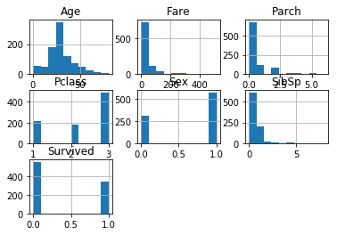

```python
df_copy.hist()
```

# Q10:

##### نرمال سازی را برای تمام ستون ها با کم کردن میانگین و تقسیم کردن بر انحراف معیار انجام میدهیم. دقت شود نرمال سازی را برای ستونی که وضعیت زنده ماندن یا نماندن را نشان میدهد انجام نمیدهیم

```python
column_header = df_copy.columns.tolist()
column_header.remove('Survived')
```

##### برای سادگی و افزایش سرعت، نرمال سازی در قسمت 11 در یک حلقه انجام میشود

# Q11:

##### ابتدا برچسب گذاری را برای ستون نام بندری که در آن مسافر سوار شده، انجام میدهیم

```python
df_copy['Embarked'] = df['Embarked'].astype('category').cat.codes
```

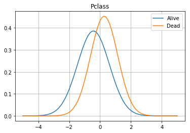

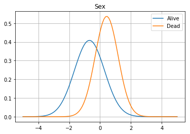

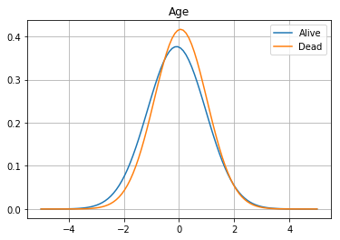

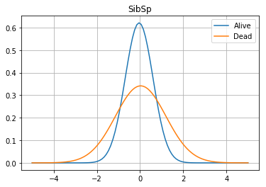

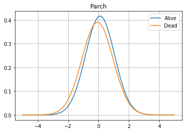

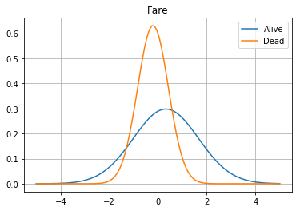

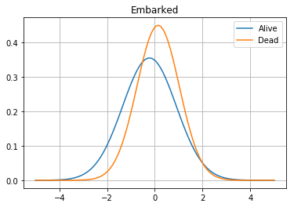

```python
Fare_threshold_1 = 0
Fare_threshold_2 = 0
Fare_Mean = 0
Fare_Std = 0

SibSp_threshold_1 = 0
SibSp_threshold_2 = 0
SibSp_Mean = 0
SibSp_Std = 0

df_copy2 = df_copy.copy()

for i in column_header :
    # نرمالیزه کردن
    df_copy[i] = (df_copy[i]-df_copy[i].mean())/df_copy[i].std()

    # میانگین و انحراف معیار افراد زنده
    Alive_mean = df_copy[df_copy['Survived'] == 1][i].mean()
    Alive_std = df_copy[df_copy['Survived'] == 1][i].std()

    # میانگین و انحراف معیار افراد مرده
    Dead_mean = df_copy[df_copy['Survived'] == 0][i].mean()
    Dead_std = df_copy[df_copy['Survived'] == 0][i].std()

    # بدست آوردن تابع چگالی احتمال، برای هر یک از گروه ها
    x = np.linspace(-5,5,100)
    y_Alive = norm.pdf(x, Alive_mean, Alive_std)
    y_Dead = norm.pdf(x, Dead_mean, Dead_std)

    # رسم نمودار
    plt.plot(x, y_Alive, label = 'Alive')
    plt.plot(x, y_Dead, label = 'Dead')
    plt.title(i)
    plt.grid()
    plt.legend()
    plt.show()

    # بدست آوردن نقاط برخورد دو نمودار و حذف مقادیر ابتدا و انتهایی
    dif =  y_Alive - y_Dead
    dif[:25] = 1
    dif[75:] = 1

    if i == 'Fare' :
        index = np.argmin(np.abs(dif))
        Fare_threshold_1 = x[index]
        dif[index] = 1
        index = np.argmin(np.abs(dif))
        Fare_threshold_2 = x[index]

        Fare_Mean = df[i].mean()
        Fare_Std = df[i].std()

    if i == 'SibSp' :
        index = np.argmin(np.abs(dif))
        SibSp_threshold_2 = x[index]
        #print(index)
        dif[index] = 1
        index = np.argmin(np.abs(dif))
        #print(index)
        SibSp_threshold_1 = x[index]

        SibSp_Mean = df[i].mean()
        SibSp_Std = df[i].std()
```

# Q12:

##### علت انتخاب این دو ویژگی، تفاوت بالای انحراف معیار نمودارهای آن میباشد که احتمال دقیقتر بودن پیش بینی را بیشتر میکند

```python
test = pd.read_csv('test.csv')

Fare = (test['Fare']-Fare_Mean)/Fare_Std

SibSp = (test['SibSp']-SibSp_Mean)/SibSp_Std

test['Survived'] = (Fare < Fare_threshold_1) | (Fare > Fare_threshold_2) | (SibSp < SibSp_threshold_1) | (SibSp > SibSp_threshold_2)

test.to_csv('test_Updated.csv')

pd.read_csv('test_Updated.csv')
```

|  | Unnamed: 0 | PassengerId | Pclass | Name | Sex | Age | SibSp | Parch | Ticket | Fare | Cabin | Embarked | Survived |
| --- | --- | --- | --- | --- | --- | --- | --- | --- | --- | --- | --- | --- | --- |
| 0 | 0 | 892 | 3 | Kelly, Mr. James | male | 34.5 | 0 | 0 | 330911 | 7.8292 | NaN | Q | False |
| 1 | 1 | 893 | 3 | Wilkes, Mrs. James (Ellen Needs) | female | 47.0 | 1 | 0 | 363272 | 7.0000 | NaN | S | False |
| 2 | 2 | 894 | 2 | Myles, Mr. Thomas Francis | male | 62.0 | 0 | 0 | 240276 | 9.6875 | NaN | Q | False |
| 3 | 3 | 895 | 3 | Wirz, Mr. Albert | male | 27.0 | 0 | 0 | 315154 | 8.6625 | NaN | S | False |
| 4 | 4 | 896 | 3 | Hirvonen, Mrs. Alexander (Helga E Lindqvist) | female | 22.0 | 1 | 1 | 3101298 | 12.2875 | NaN | S | False |
| 5 | 5 | 897 | 3 | Svensson, Mr. Johan Cervin | male | 14.0 | 0 | 0 | 7538 | 9.2250 | NaN | S | False |
| 6 | 6 | 898 | 3 | Connolly, Miss. Kate | female | 30.0 | 0 | 0 | 330972 | 7.6292 | NaN | Q | False |
| 7 | 7 | 899 | 2 | Caldwell, Mr. Albert Francis | male | 26.0 | 1 | 1 | 248738 | 29.0000 | NaN | S | False |
| 8 | 8 | 900 | 3 | Abrahim, Mrs. Joseph (Sophie Halaut Easu) | female | 18.0 | 0 | 0 | 2657 | 7.2292 | NaN | C | False |
| 9 | 9 | 901 | 3 | Davies, Mr. John Samuel | male | 21.0 | 2 | 0 | A/4 48871 | 24.1500 | NaN | S | True |
| 10 | 10 | 902 | 3 | Ilieff, Mr. Ylio | male | NaN | 0 | 0 | 349220 | 7.8958 | NaN | S | False |
| 11 | 11 | 903 | 1 | Jones, Mr. Charles Cresson | male | 46.0 | 0 | 0 | 694 | 26.0000 | NaN | S | False |
| 12 | 12 | 904 | 1 | Snyder, Mrs. John Pillsbury (Nelle Stevenson) | female | 23.0 | 1 | 0 | 21228 | 82.2667 | B45 | S | True |
| 13 | 13 | 905 | 2 | Howard, Mr. Benjamin | male | 63.0 | 1 | 0 | 24065 | 26.0000 | NaN | S | False |
| 14 | 14 | 906 | 1 | Chaffee, Mrs. Herbert Fuller (Carrie Constance... | female | 47.0 | 1 | 0 | W.E.P. 5734 | 61.1750 | E31 | S | True |
| 15 | 15 | 907 | 2 | del Carlo, Mrs. Sebastiano (Argenia Genovesi) | female | 24.0 | 1 | 0 | SC/PARIS 2167 | 27.7208 | NaN | C | False |
| 16 | 16 | 908 | 2 | Keane, Mr. Daniel | male | 35.0 | 0 | 0 | 233734 | 12.3500 | NaN | Q | False |
| 17 | 17 | 909 | 3 | Assaf, Mr. Gerios | male | 21.0 | 0 | 0 | 2692 | 7.2250 | NaN | C | False |
| 18 | 18 | 910 | 3 | Ilmakangas, Miss. Ida Livija | female | 27.0 | 1 | 0 | STON/O2. 3101270 | 7.9250 | NaN | S | False |
| 19 | 19 | 911 | 3 | Assaf Khalil, Mrs. Mariana (Miriam")" | female | 45.0 | 0 | 0 | 2696 | 7.2250 | NaN | C | False |
| 20 | 20 | 912 | 1 | Rothschild, Mr. Martin | male | 55.0 | 1 | 0 | PC 17603 | 59.4000 | NaN | C | False |
| 21 | 21 | 913 | 3 | Olsen, Master. Artur Karl | male | 9.0 | 0 | 1 | C 17368 | 3.1708 | NaN | S | False |
| 22 | 22 | 914 | 1 | Flegenheim, Mrs. Alfred (Antoinette) | female | NaN | 0 | 0 | PC 17598 | 31.6833 | NaN | S | False |
| 23 | 23 | 915 | 1 | Williams, Mr. Richard Norris II | male | 21.0 | 0 | 1 | PC 17597 | 61.3792 | NaN | C | True |
| 24 | 24 | 916 | 1 | Ryerson, Mrs. Arthur Larned (Emily Maria Borie) | female | 48.0 | 1 | 3 | PC 17608 | 262.3750 | B57 B59 B63 B66 | C | True |
| 25 | 25 | 917 | 3 | Robins, Mr. Alexander A | male | 50.0 | 1 | 0 | A/5. 3337 | 14.5000 | NaN | S | False |
| 26 | 26 | 918 | 1 | Ostby, Miss. Helene Ragnhild | female | 22.0 | 0 | 1 | 113509 | 61.9792 | B36 | C | True |
| 27 | 27 | 919 | 3 | Daher, Mr. Shedid | male | 22.5 | 0 | 0 | 2698 | 7.2250 | NaN | C | False |
| 28 | 28 | 920 | 1 | Brady, Mr. John Bertram | male | 41.0 | 0 | 0 | 113054 | 30.5000 | A21 | S | False |
| 29 | 29 | 921 | 3 | Samaan, Mr. Elias | male | NaN | 2 | 0 | 2662 | 21.6792 | NaN | C | True |
| ... | ... | ... | ... | ... | ... | ... | ... | ... | ... | ... | ... | ... | ... |
| 388 | 388 | 1280 | 3 | Canavan, Mr. Patrick | male | 21.0 | 0 | 0 | 364858 | 7.7500 | NaN | Q | False |
| 389 | 389 | 1281 | 3 | Palsson, Master. Paul Folke | male | 6.0 | 3 | 1 | 349909 | 21.0750 | NaN | S | True |
| 390 | 390 | 1282 | 1 | Payne, Mr. Vivian Ponsonby | male | 23.0 | 0 | 0 | 12749 | 93.5000 | B24 | S | True |
| 391 | 391 | 1283 | 1 | Lines, Mrs. Ernest H (Elizabeth Lindsey James) | female | 51.0 | 0 | 1 | PC 17592 | 39.4000 | D28 | S | False |
| 392 | 392 | 1284 | 3 | Abbott, Master. Eugene Joseph | male | 13.0 | 0 | 2 | C.A. 2673 | 20.2500 | NaN | S | False |
| 393 | 393 | 1285 | 2 | Gilbert, Mr. William | male | 47.0 | 0 | 0 | C.A. 30769 | 10.5000 | NaN | S | False |
| 394 | 394 | 1286 | 3 | Kink-Heilmann, Mr. Anton | male | 29.0 | 3 | 1 | 315153 | 22.0250 | NaN | S | True |
| 395 | 395 | 1287 | 1 | Smith, Mrs. Lucien Philip (Mary Eloise Hughes) | female | 18.0 | 1 | 0 | 13695 | 60.0000 | C31 | S | True |
| 396 | 396 | 1288 | 3 | Colbert, Mr. Patrick | male | 24.0 | 0 | 0 | 371109 | 7.2500 | NaN | Q | False |
| 397 | 397 | 1289 | 1 | Frolicher-Stehli, Mrs. Maxmillian (Margaretha ... | female | 48.0 | 1 | 1 | 13567 | 79.2000 | B41 | C | True |
| 398 | 398 | 1290 | 3 | Larsson-Rondberg, Mr. Edvard A | male | 22.0 | 0 | 0 | 347065 | 7.7750 | NaN | S | False |
| 399 | 399 | 1291 | 3 | Conlon, Mr. Thomas Henry | male | 31.0 | 0 | 0 | 21332 | 7.7333 | NaN | Q | False |
| 400 | 400 | 1292 | 1 | Bonnell, Miss. Caroline | female | 30.0 | 0 | 0 | 36928 | 164.8667 | C7 | S | True |
| 401 | 401 | 1293 | 2 | Gale, Mr. Harry | male | 38.0 | 1 | 0 | 28664 | 21.0000 | NaN | S | False |
| 402 | 402 | 1294 | 1 | Gibson, Miss. Dorothy Winifred | female | 22.0 | 0 | 1 | 112378 | 59.4000 | NaN | C | False |
| 403 | 403 | 1295 | 1 | Carrau, Mr. Jose Pedro | male | 17.0 | 0 | 0 | 113059 | 47.1000 | NaN | S | False |
| 404 | 404 | 1296 | 1 | Frauenthal, Mr. Isaac Gerald | male | 43.0 | 1 | 0 | 17765 | 27.7208 | D40 | C | False |
| 405 | 405 | 1297 | 2 | Nourney, Mr. Alfred (Baron von Drachstedt")" | male | 20.0 | 0 | 0 | SC/PARIS 2166 | 13.8625 | D38 | C | False |
| 406 | 406 | 1298 | 2 | Ware, Mr. William Jeffery | male | 23.0 | 1 | 0 | 28666 | 10.5000 | NaN | S | False |
| 407 | 407 | 1299 | 1 | Widener, Mr. George Dunton | male | 50.0 | 1 | 1 | 113503 | 211.5000 | C80 | C | True |
| 408 | 408 | 1300 | 3 | Riordan, Miss. Johanna Hannah"" | female | NaN | 0 | 0 | 334915 | 7.7208 | NaN | Q | False |
| 409 | 409 | 1301 | 3 | Peacock, Miss. Treasteall | female | 3.0 | 1 | 1 | SOTON/O.Q. 3101315 | 13.7750 | NaN | S | False |
| 410 | 410 | 1302 | 3 | Naughton, Miss. Hannah | female | NaN | 0 | 0 | 365237 | 7.7500 | NaN | Q | False |
| 411 | 411 | 1303 | 1 | Minahan, Mrs. William Edward (Lillian E Thorpe) | female | 37.0 | 1 | 0 | 19928 | 90.0000 | C78 | Q | True |
| 412 | 412 | 1304 | 3 | Henriksson, Miss. Jenny Lovisa | female | 28.0 | 0 | 0 | 347086 | 7.7750 | NaN | S | False |
| 413 | 413 | 1305 | 3 | Spector, Mr. Woolf | male | NaN | 0 | 0 | A.5. 3236 | 8.0500 | NaN | S | False |
| 414 | 414 | 1306 | 1 | Oliva y Ocana, Dona. Fermina | female | 39.0 | 0 | 0 | PC 17758 | 108.9000 | C105 | C | True |
| 415 | 415 | 1307 | 3 | Saether, Mr. Simon Sivertsen | male | 38.5 | 0 | 0 | SOTON/O.Q. 3101262 | 7.2500 | NaN | S | False |
| 416 | 416 | 1308 | 3 | Ware, Mr. Frederick | male | NaN | 0 | 0 | 359309 | 8.0500 | NaN | S | False |
| 417 | 417 | 1309 | 3 | Peter, Master. Michael J | male | NaN | 1 | 1 | 2668 | 22.3583 | NaN | C | False |

418 rows × 13 columns